# UPA_projekt-04

Tim 9: Mateo Roksandić, Matej Marijan, Matea Adlašić, Karlo Kurtanjek

# Analiza mreže

```r
# Učitavanje podataka za daljnju obradu podataka
Podaci <- read_excel("Data_SNA.xlsx")
colnames(Podaci)
```

```
## [1] "Ime i prezime"
## [2] "Spol"
## [3] "Osoba kraj koje najčešće sjedim u učionici"
## [4] "Osoba od koje najčešće tražim pomoć"
```

```r
names(Podaci)<-c("ImeiPrezime", "Spol", "OsobaKrajKojeNajcesceSjedimuUcionici", "OsobaOdKojeNajcesceTrazimPomoc")

options(width = 100)
head(Podaci,100)
```

```
## # A tibble: 55 × 4
##    ImeiPrezime Spol  OsobaKrajKojeNajcesceSjedimuUcionici OsobaOdKojeNajcesceTrazimPomoc
##    <chr>       <chr> <chr>                                <chr>
##  1 Domagoj B   M     Nikola B                             Sven Š
##  2 Jurica I    M     Ines K                               Ines K
##  3 Karlo Ju    M     Gabrijel D                           Ante K
##  4 Jelena T    Z     Barbara Č                            Barbara Č
##  5 Matea A     Z     Ema T                                Ema T
##  6 Alen A      M     Gabrijel D                           Roberto M
##  7 Nikola B    M     Martina K                            Martina K
##  8 Alan C      M     Lorena J                             Lorena J
##  9 Barbara Č   Z     Jelena T                             Jelena T
## 10 Gabrijel D  M     Fran S                               Alen A
## # ℹ 45 more rows
```

```r
# Selektiranje relevantnih stupaca
PodaciSjedenje <- select(Podaci, ImeiPrezime, OsobaKrajKojeNajcesceSjedimuUcionici)
PodaciPomoc <- select(Podaci, ImeiPrezime, OsobaOdKojeNajcesceTrazimPomoc)
PodaciSpol <- select(Podaci, Spol)
```

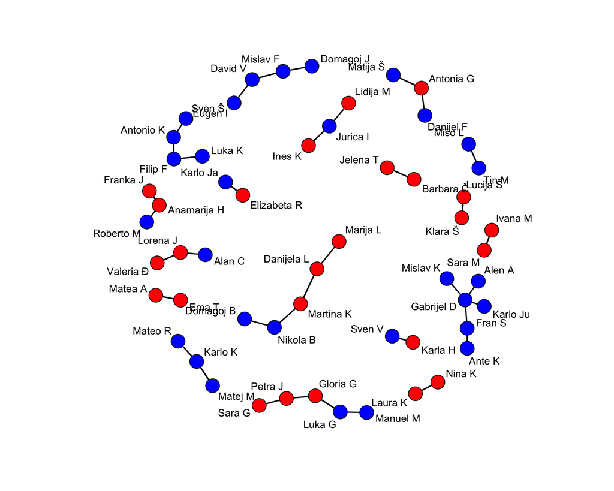

```r
# Kreiranje boja na osnovu spola
boje <- ifelse(Podaci$Spol == "M", "blue", "red")

# Kreiranje mreže za sjedenje
MrezaSjedenje <- network(PodaciSjedenje, directed = FALSE, loops = TRUE, multiple = TRUE)
set.vertex.attribute(MrezaSjedenje, "spol", PodaciSpol$Spol) #dodavanje spola mreži sjedenja

# Vizualizacija mreže sjedenja
plot(MrezaSjedenje, edge.lwd = 2, edge.col = "black", displaylabels = TRUE, vertex.col = boje, vertex.cex = 2, mode = "fruchtermanreingold")
```

```r
# Deskriptivna statistika mreže sjedenja
cat("Deskriptivna statistika za mrežu sjedenja:\n")
```

```
## Deskriptivna statistika za mrežu sjedenja:
```

```r
gden(MrezaSjedenje) # Gustoća mreže
```

```
## [1] 0.03703704
```

```r
degree(MrezaSjedenje) # Stupnjevi čvorova
```

```
##  [1] 2 6 2 4 4 2 4 2 4 8 4 6 6 2 6 6 6 2 6 4 2 2 4 4 6 4 2 4 6 4 4 4 4 4 6 6 4 2 4 2 4 4 2 4 2 4 2 6
## [49] 4 2 4 4 4 6 4
```

```r
network.size(MrezaSjedenje) # Broj čvorova
```

```
## [1] 55
```

```r
network.edgecount(MrezaSjedenje) # Broj bridova
```

```
## [1] 55
```

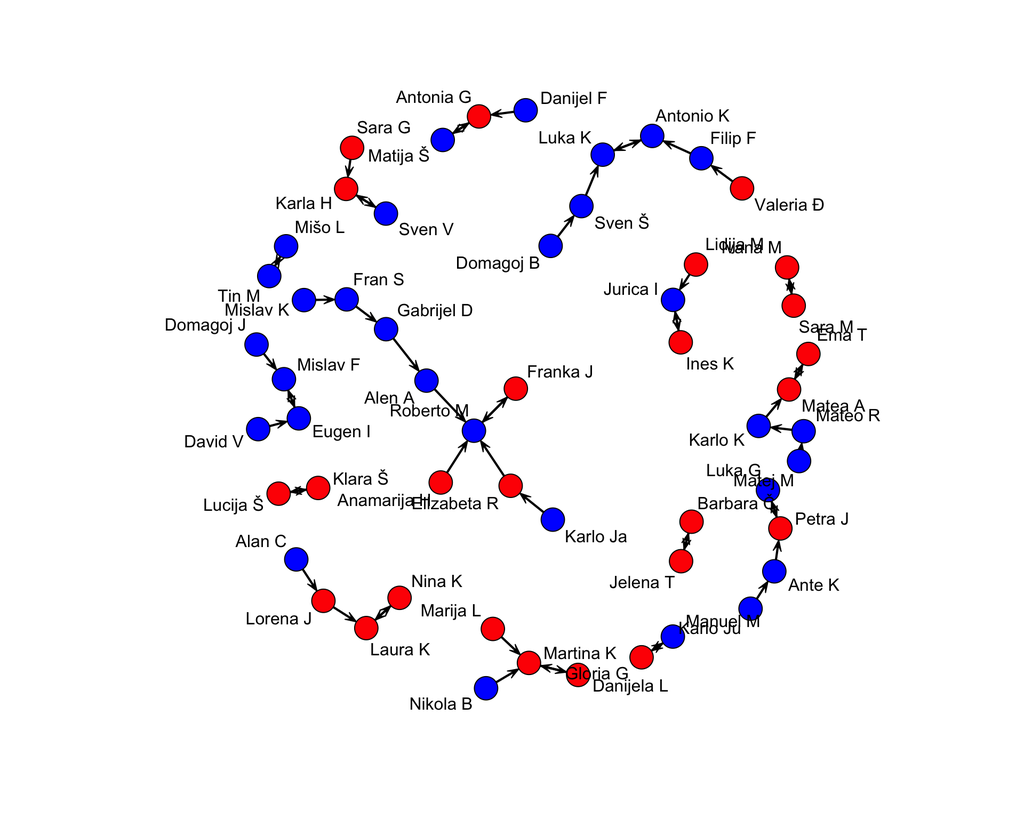

```r
# Kreiranje mreže za traženje pomoći
MrezaPomoc <- network(PodaciPomoc, directed=T, loops=TRUE, multiple=TRUE)
set.vertex.attribute(MrezaPomoc, "spol", PodaciSpol) #dodavanje spola mreži pomoći

# Vizualizacija mreže sjedenja
plot(MrezaPomoc, edge.lwd = 2, edge.col = "black", displaylabels = TRUE, vertex.col = boje, vertex.cex = 2, mode = "fruchtermanreingold")
```

```r
# Deskriptivna statistika mreže sjedenja
cat("Deskriptivna statistika za mrežu traženja pomoći:\n")
```

```
## Deskriptivna statistika za mrežu traženja pomoći:
```

```r
gden(MrezaPomoc) # Gustoća mreže
```

```
## [1] 0.01851852
```

```r
degree(MrezaPomoc) # Stupnjevi čvorova
```

```
##  [1] 1 3 1 2 3 2 1 1 2 2 1 2 3 1 2 2 3 1 1 3 3 1 1 2 2 3 1 3 4 2 3 2 2 3 2 2 2 1 2 5 1 2 2 2 1 2 2 2
## [49] 2 2 2 2 2 1 2
```

```r
network.size(MrezaPomoc) # Broj čvorova
```

```
## [1] 55
```

```r
network.edgecount(MrezaPomoc) # Broj bridova
```

```
## [1] 55
```

**Mreža sjedenja** Mreža sjedenja predstavlja socijalne interakcije među sudionicima, pri čemu čvorovi predstavljaju pojedince, a bridovi označavaju prisustvo zajedničkog sjedenja. Graf je neusmjeren, što znači da prisustvo sjedenja nije povezano s određenim smjerom. Gustoća grafa: 0.03703704 Broj čvorova: 55 Broj bridova: 55 Stupnjevi čvorova: Različiti čvorovi imaju različite stupnjeve, s najmanje 2 i najviše 8.

**Mreža traženja pomoći** Mreža traženja pomoći predstavlja usmjereni graf socijalnih interakcija među pojedincima, pri čemu čvorovi opet predstavljaju pojedince, a usmjereni bridovi označavaju traženje pomoći od jednog pojedinca prema drugome. Graf je usmjeren, što znači da postoji smjer u kojem se odvijaju interakcije. Gustoća grafa: 0.01851852 Broj čvorova: 55 Broj bridova: 55 Stupnjevi čvorova: Različiti čvorovi imaju različite stupnjeve, s najmanje 1 i najviše 5.

# Traženje pomoći po spolu

```r
# Izračun stupanja centralnosti za svaki čvor
degree_centralities <- degree(MrezaPomoc, gmode="graph")

# Dodavanje stupnja centralnosti kao atribut u mrežu
MrezaPomoc %v% 'degree' <- degree_centralities

# Izračun prosječne centralnosti za muškarce i žene
average_degree_m <- mean(degree_centralities[MrezaPomoc %v% 'spol' == 'M'], na.rm = TRUE)
average_degree_z <- mean(degree_centralities[MrezaPomoc %v% 'spol' == 'Z'], na.rm = TRUE)

# Dohvaćanje edgelist
edgelist <- as.edgelist(MrezaPomoc)

# Dohvaćanje spol za svaki čvor
spol_cvorova <- MrezaPomoc %v% "spol"

# Izračun broja veza između muškaraca i muškaraca
broj_m_m <- sum(spol_cvorova[edgelist[, 1]] == "M" & spol_cvorova[edgelist[, 2]] == "M")

# Izračun broja veza između žena i žena
broj_z_z <- sum(spol_cvorova[edgelist[, 1]] == "Z" & spol_cvorova[edgelist[, 2]] == "Z")

# Izračun broja veza između muškaraca i žena
broj_m_z <- sum(spol_cvorova[edgelist[, 1]] == "M" & spol_cvorova[edgelist[, 2]] == "Z")

# Izračun broja veza između žena i muškaraca
broj_z_m <- sum(spol_cvorova[edgelist[, 1]] == "Z" & spol_cvorova[edgelist[, 2]] == "M")


# Ispis rezultata
cat("Prosjek stupnja centralnosti za muškarce:", average_degree_m, "\n")
```

Prosjek stupnja centralnosti za muškarce: 0.9333333

```r
cat("Prosjek stupnja centralnosti za žene:", average_degree_z, "\n")
```

Prosjek stupnja centralnosti za žene: 1.08

```r
cat("Broj veza između muškaraca i muškaraca:", broj_m_m, "\n")
```

Broj veza između muškaraca i muškaraca: 18

```r
cat("Broj veza između žena i žena:", broj_z_z, "\n")
```

Broj veza između žena i žena: 15

```r
cat("Broj veza između muškaraca i žena:", broj_m_z+broj_z_m, "\n")
```

Broj veza između muškaraca i žena: 22

Prosjek stupnja centralnosti za muškarce iznosi 0.9333333, dok za žene iznosi 1.08. Ovi rezultati ukazuju na nešto veći prosječni stupanj centralnosti za žene u usporedbi s muškarcima u mreži traženja pomoći. To implicira da žene, u prosjeku, imaju više veza ili su češće tražene za pomoć u ovoj socijalnoj mreži. Iako postoji razlika u prosječnim stupnjevima centralnosti između muškaraca i žena, ta razlika nije vrlo velika. Ova mala razlika sugerira da, iako može postojati određena tendencija, spol ne igra ključnu ulogu u određivanju centralnosti unutar ove mreže traženja pomoći. Odnosno, spolovi se ne razlikuju značajno u kontekstu traženja pomoći unutar ove socijalne mreže.

Iz analize socijalne mreže proizlazi da unutar grupe postoji određena preferencija, no ne velika, kod muškaraca da traže pomoć od drugih muškaraca, što potvrđuje broj veza između muškaraca (M-M: 18). Sličan obrazac opaža se i među ženama, gdje broj veza između žena (Ž-Ž: 15) ukazuje na često traženje podrške unutar vlastitog spola. No, važno je primijetiti da postoji značajan broj veza između muškaraca i žena (M-Ž: 22), sugerirajući otvorenost za suradnju između spolova. Stoga, iako postoji tendencija traženja pomoći od osoba istog spola, prisutna je i suradnja između muškaraca i žena, ukazujući na to da spol sam po sebi možda nije presudan faktor pri odabiru osobe za pomoć unutar ove grupe.

# Grupiranje studenata

```r
# Provjera je li 'MrezaSjedenje' kompatibilan s 'igraph' funkcijama
if(!inherits(MrezaSjedenje, "igraph")) {
  # Konverzija u 'igraph' objekt
  MrezaSjedenje <- igraph::graph_from_data_frame(as.data.frame(MrezaSjedenje), directed = FALSE)
}

# Kreiranje matrice susjedstva za mrežu sjedenja bez atributa 'spol'
matrica_susjedstva_sjedenje <- igraph::as_adjacency_matrix(MrezaSjedenje, sparse = FALSE)


# Kreiranje matrice susjedstva za mrežu sjedenja
matrica_susjedstva_sjedenje <- igraph::as_adjacency_matrix(MrezaSjedenje, sparse = FALSE)

# Definiranje raspona broja klastera koje se ispituje
raspon_klastera <- 2:10

# Inicijalizacija vektora za pohranu rezultata siluete
silueta_vrijednosti <- numeric(length(raspon_klastera))

set.seed(123)
# Izračun siluete za svaki broj klastera u rasponu
for (k in raspon_klastera) {
  kmeans_model <- kmeans(matrica_susjedstva_sjedenje, centers = k)
  silueta_vrijednosti[k - min(raspon_klastera) + 1] <- mean(silhouette(kmeans_model$cluster, dist(matrica_susjedstva_sjedenje)))
}

# Pronalaženje broja klastera koji maksimizira siluetu
optimalni_broj_klastera <- raspon_klastera[which.max(silueta_vrijednosti)]

# Ispisivanje optimalnog broja klastera
cat("Optimalan broj klastera prema metodi siluete:", optimalni_broj_klastera, "\n")
```

```
## Optimalan broj klastera prema metodi siluete: 9
```

```r
# Izračun k-sredine s optimalnim brojem klastera
kmeans_model <- kmeans(matrica_susjedstva_sjedenje, centers = optimalni_broj_klastera)

# Crtanje grafikona siluete
silhouette_plot <- fviz_silhouette(silhouette(kmeans_model$cluster, dist(matrica_susjedstva_sjedenje)))
```

```
##   cluster size ave.sil.width
## 1       1    2          0.31
## 2       2   15         -0.05
## 3       3    2          0.18
## 4       4    4          0.55
## 5       5    1          0.00
## 6       6    2          0.31
## 7       7   22         -0.13
## 8       8    2          0.23
## 9       9    5         -0.11
```

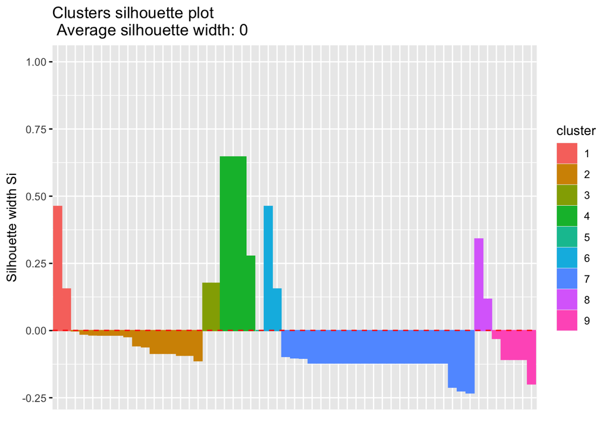

```r
# Prikazivanje grafikona
print(silhouette_plot)
```

Tijekom analize mreže sjedenja, primijetili smo da postoji vidljiva grupacija studenata koji često sjede zajedno. Ovo ukazuje na to da određeni studenti preferiraju druženje u skupinama tijekom različitih aktivnosti.

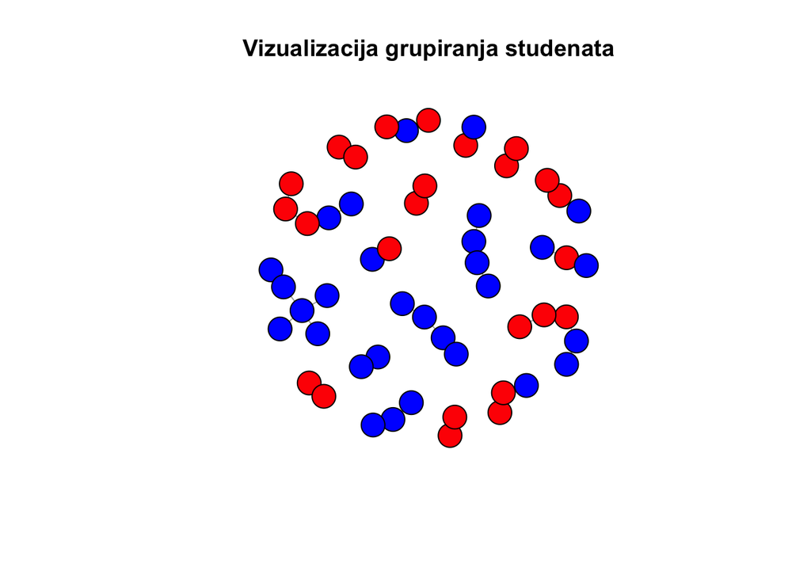

```r
# Pretvorba matrice susjedstva u graf
graf_sjedenje <- graph_from_adjacency_matrix(matrica_susjedstva_sjedenje, mode = "undirected")
# Dohvaćanje imena čvorova koji su muškog spola
muski_cvorovi <- Podaci$ImeiPrezime[Podaci$Spol == "M"]

# Postavljanje boja čvorova na temelju spola
V(graf_sjedenje)$color <- ifelse(V(graf_sjedenje)$name %in% muski_cvorovi, "blue", "red")

# Povećavanje veličine čvorova
velicina_cvorova <- 20

# Podešavanje Fruchterman-Reingold algoritma s većim brojem iteracija i većom površinom
layout <- layout_with_fr(graf_sjedenje, niter=1000)

# Vizualizacija grafa s prilagođenim rasporedom
plot(graf_sjedenje, layout=layout, vertex.label=NA, main="Vizualizacija grupiranja studenata")
```

```r
# Uklanjanje redova s praznim vrijednostima za relevantne stupce
Podaci <- Podaci %>%
  filter(OsobaKrajKojeNajcesceSjedimuUcionici != "", OsobaOdKojeNajcesceTrazimPomoc != "")

# Provjera je li 'MrezaSjedenje' kompatibilan s 'igraph' funkcijama
if(!"igraph" %in% class(MrezaSjedenje)) {
  # Konverzija u 'igraph' objekt
  MrezaSjedenje <- igraph::graph_from_data_frame(as.data.frame(MrezaSjedenje), directed = FALSE)
}

# Provjera broja klastera
if(!exists("broj
klastera")) {
broj_klastera <- 9
}

k_sredine_rezultati <- kmeans(matrica_susjedstva_sjedenje, centers = broj_klastera)

broj_redova_izvorni <- nrow(Podaci)

broj_redova_klasteri <- length(k_sredine_rezultati$cluster)

if(broj_redova_izvorni != broj_redova_klasteri) {
k_sredine_rezultati$cluster <- rep(k_sredine_rezultati$cluster, length.out = broj_redova_izvorni)
}

Podaci <- Podaci %>%
mutate(GrupaSjedenje = k_sredine_rezultati$cluster)

cat("Rezultati grupiranja korisnika prema mreži sjedenja (K-sredine):\n")
```

```
## Rezultati grupiranja korisnika prema mreži sjedenja (K-sredine):
```

```r
table(Podaci$GrupaSjedenje)
```

```
##
##  1  2  3  4  5  6  7  8  9
##  1  2 40  2  1  1  2  2  4
```

Rezultati koji se prikazuju u tablici nakon grupiranja koristeći K-sredine (K-means) algoritma odražavaju broj članova koji su dodijeljeni svakom klasteru. U ovom slučaju, metoda siluete identificirala je 9 različitih klastera.

U devetom klasteru se nalaze 4 osobe. Ovakav klaster predstavlja manju skupinu čiji članovi obično sjede zajedno.

Klaster 2, Klaster 4, Klaster 7, i Klaster 8 imaju po dva člana koji sjede zajedno.

# Jesu li u grupama sve osobe istog spola

```r
# Tablica grupa i spolova
tablica_grupa_spol <- table(Podaci$GrupaSjedenje, Podaci$Spol)

# Ispis rezultata
cat("Provjera spolova u grupama:\n")
```

```
## Provjera spolova u grupama:
```

```r
print(tablica_grupa_spol)
```

```
##
##      M  Z
##   1  0  1
##   2  2  0
##   3 20 20
##   4  1  1
##   5  1  0
##   6  0  1
##   7  2  0
##   8  1  1
##   9  3  1
```

```r
# Provjera jesu li u svim grupama sve osobe istog spola
sve_osobe_istog_spola <- all(tablica_grupa_spol[, 1] == 0 | tablica_grupa_spol[, 2] == 0)

if (sve_osobe_istog_spola) {
  cat("U svim grupama su sve osobe istog spola.\n")
} else {
  cat("U nekim grupama se nalaze osobe različitog spola.\n")
}
```

```
## U nekim grupama se nalaze osobe različitog spola.
```

```r
# Stvaranje tablice kontingencije za broj grupa s različitim kombinacijama spolova
tablica_grupa_spol <- table(Podaci$GrupaSjedenje, Podaci$Spol)

# Broj grupa samo s muškarcima
broj_grupa_s_muskaracima <- sum(tablica_grupa_spol[, "M"] > 0 & tablica_grupa_spol[, "Z"] == 0)

# Broj grupa samo sa ženama
broj_grupa_s_zenama <- sum(tablica_grupa_spol[, "Z"] > 0 & tablica_grupa_spol[, "M"] == 0)

# Ispis rezultata
cat("Broj grupa samo s muškarcima:", broj_grupa_s_muskaracima, "\n")
```

```
## Broj grupa samo s muškarcima: 3
```

```r
cat("Broj grupa samo s ženama:", broj_grupa_s_zenama, "\n")
```

```
## Broj grupa samo s ženama: 2
```

# Postoji li osoba oko koje sjedi najveći broj ljudi

```r
broj_sjedenja <- table(Podaci$OsobaKrajKojeNajcesceSjedimuUcionici)

# Traženje osobe s najvećim brojem susjeda
osoba_sa_najvecim_brojem_sjedenja <- data.frame(
  ImeiPrezime = names(broj_sjedenja),
  BrojSjedenja = as.numeric(broj_sjedenja)
)

osoba_sa_najvecim_brojem_sjedenja <- osoba_sa_najvecim_brojem_sjedenja[order(-osoba_sa_najvecim_brojem_sjedenja$BrojSjedenja), ]

# Ispis osobe s najvećim brojem susjeda i broj sjedenja
cat("Osoba oko koje sjedi najveći broj studenata:\n")
```

```
## Osoba oko koje sjedi najveći broj studenata:
```

```r
print(osoba_sa_najvecim_brojem_sjedenja$ImeiPrezime[1])
```

```
## [1] "Gabrijel D"
```

```r
cat("Broj studenata koji sjede oko te osobe:\n")
```

```
## Broj studenata koji sjede oko te osobe:
```

```r
print(osoba_sa_najvecim_brojem_sjedenja$BrojSjedenja[1])
```

```
## [1] 3
```

Prema analizi podataka, “Gabrijel D” se ističe kao osoba oko koje sjedi najveći broj studenata, s ukupno troje studenata u blizini. Ovaj rezultat sugerira da je “Gabrijel D” centralna figura u kontekstu rasporeda sjedenja, budući da ga okružuje veći broj studenata u usporedbi s ostalim osobama. Važno je napomenuti da broj studenata koji sjedi oko određene osobe može ukazivati na njezinu društvenu ulogu u grupi ili povezanost sa studentima.

# Osoba koju se najviše tražilo pomoć

```r
# Filtriranje redove s praznim vrijednostima i praznim nizom znakova u stupcu "OsobaOdKojeNajcesceTrazimPomoc"
Podaci <- Podaci[!is.na(Podaci$OsobaOdKojeNajcesceTrazimPomoc) & Podaci$OsobaOdKojeNajcesceTrazimPomoc != "", ]

#  Izračun broja pojavljivanja najčešće traženih osoba
broj_pojavljivanja <- table(Podaci$OsobaOdKojeNajcesceTrazimPomoc)

# Osobe koje se pojavljuju najčešće
najcesce_osobe <- names(broj_pojavljivanja[broj_pojavljivanja == max(broj_pojavljivanja)])

# Ispis najutjecajnije osobe
cat("Najutjecajnija osoba u mreži traženja pomoći:\n")
```

```
## Najutjecajnija osoba u mreži traženja pomoći:
```

```r
print(najcesce_osobe)
```

```
## [1] "Roberto M"
```

```r
# Broj puta kad je najutjecajnija osoba tražena
cat("Broj puta kad je najutjecajnija osoba tražena:\n")
```

```
## Broj puta kad je najutjecajnija osoba tražena:
```

```r
print(max(broj_pojavljivanja))
```

```
## [1] 4
```

Prema analizi mreže pomoći, osoba koju bih predložili kao kandidata za demonstratore iz UPA-e su oni koji se ističu kao centralne figure u mreži, a istovremeno imaju značajan broj povezanosti i traženja pomoći. U ovom kontekstu, “Roberto M” se pojavljuje kao najutjecajnija osoba u mreži traženja pomoći, s ukupno četiri puta kada je tražen. Ovaj rezultat ukazuje na njegovu visoku društvenu važnost i potencijalnu sposobnost da bude efikasan demonstrator. Preporučivanje demonstratora može se temeljiti na njihovoj sposobnosti da pruže pomoć, ali i na njihovoj socijalnoj povezanosti unutar grupe, što dodatno podržava njihovu efikasnost u komunikaciji i podršci unutar grupe. Ova kombinacija pomoći i povezanosti čini ga pouzdanim izborom za demonstratore, budući da će vjerojatno uspješno komunicirati s kolegama i pružati im potrebnu pomoć. Stoga, preporuka za “Roberta M” kao kandidata za demonstratore čini se kao najbolji odabir jer je spreman za pomoć i najviše studenata ga pita za pomoć.